# Kolokvij 1 - Matjaž

Urban Matjaz

2025-01-23

# Naloga 1

```r
data = read.table("diamanti.txt", header=T)

dim(data) # dimenzije vrstice, stolpci
```

```
## [1] 321   3
```

```r
head(data) # začetek tabele
```

```
##   karat             barva cena
## 1  0.42        Brezbarven  773
## 2  0.55        Brezbarven 1580
## 3  1.15        Brezbarven 7662
## 4  0.72 Skoraj brezbarven 1866
## 5  1.08 Skoraj brezbarven 6561
## 6  0.73        Brezbarven 3255
```

```r
str(data)
```

```
## 'data.frame':    321 obs. of  3 variables:
##  $ karat: num  0.42 0.55 1.15 0.72 1.08 0.73 0.72 0.91 0.53 0.6 ...
##  $ barva: chr  "Brezbarven" "Brezbarven" "Brezbarven" "Skoraj brezbarven" ...
##  $ cena : int  773 1580 7662 1866 6561 3255 1808 3726 1093 2484 ...
```

```r
summary(data) # min, max, kvantili, povprečje po spr
```

```
##      karat           barva                cena
##  Min.   :0.2300   Length:321         Min.   :  357
##  1st Qu.:0.4000   Class :character   1st Qu.:  936
##  Median :0.7000   Mode  :character   Median : 2315
##  Mean   :0.8092                      Mean   : 3978
##  3rd Qu.:1.0600                      3rd Qu.: 5457
##  Max.   :2.7500                      Max.   :17856
```

```r
data$barva = factor(data$barva, labels = c("Brezbarven", "Skoraj brezbarven", "Rumen"))
```

Imamo podatke o diamantih. Imamo 3 spremenljivke, in sicer ceno, barvo in karat. V tem podatkovnem setu je cena odvisna spremenljivka, karat in barva pa napovedni spremenljivki.

- Cena: Številska spremenljivka, min: 357, max: 17856, mean: 3978, median: 2315
- Barva: Opisna spremenljivka s 3 vrednostmi: Brezbarven, Skoraj brezbarven, Rumen
- Karat: Številska spremenljivka, min: 0.23, max: 2.75, mean: 0.81, median: 0,7

# Naloga 2

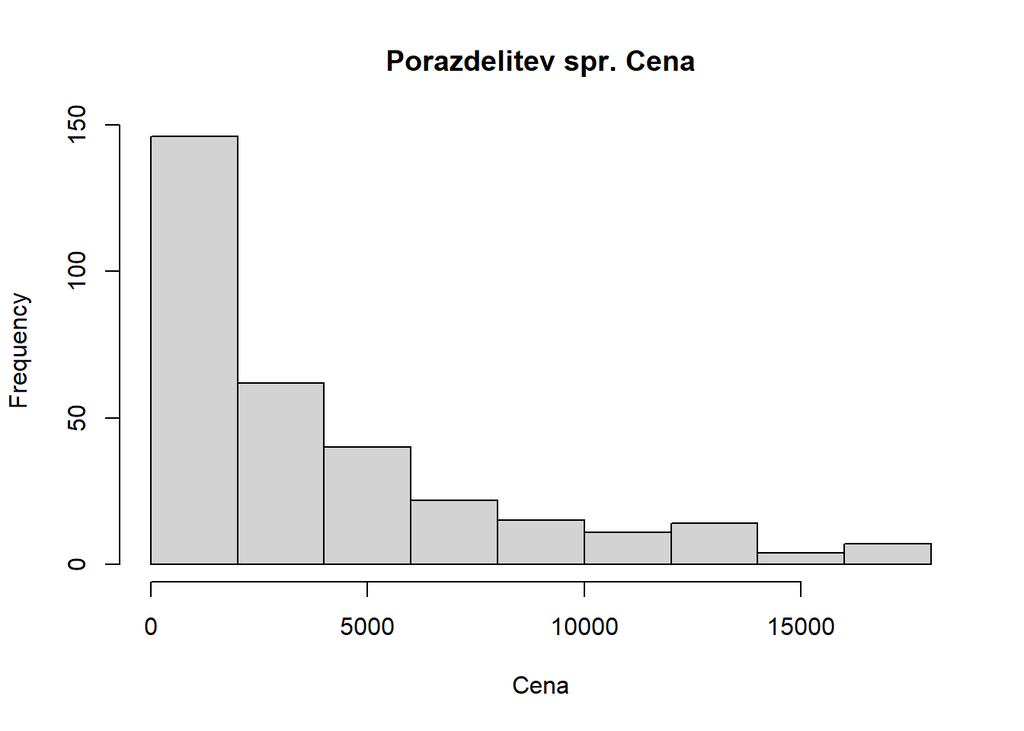

```r
hist(data$cena, main = "Porazdelitev spr. Cena", xlab = "Cena")
```

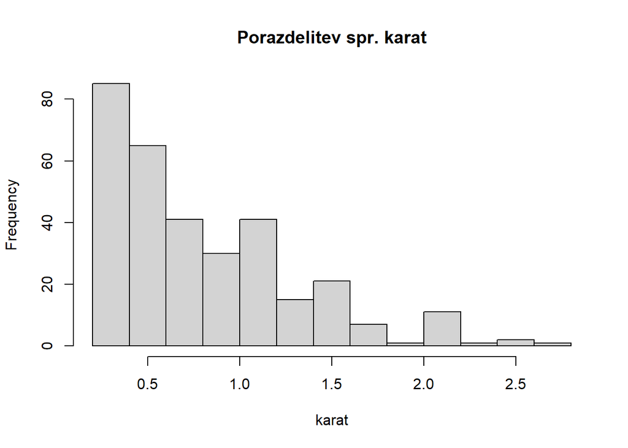

```r
hist(data$karat, main = "Porazdelitev spr. karat", xlab = "karat")
```

Iz histogramov vidimo, da se tako Cena kot tudi Karat porazdeljujeta zelo asimetrično v desno.

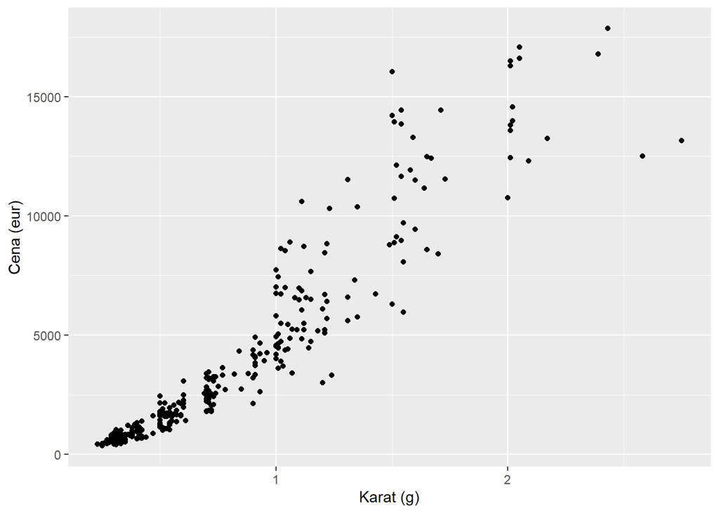

```r
ggplot(data = data) +
  geom_point(mapping = aes(x = karat, y = cena)) +
  xlab("Karat (g)") + ylab("Cena (eur)")
```

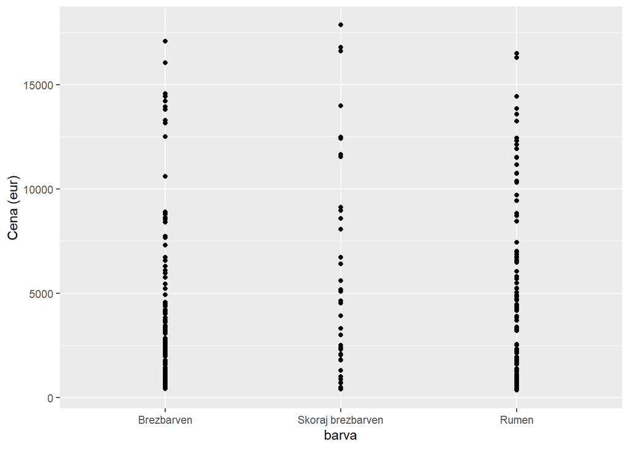

```r
ggplot(data = data) +
  geom_point(mapping = aes(x = barva, y = cena)) +
  xlab("barva") + ylab("Cena (eur)")
```

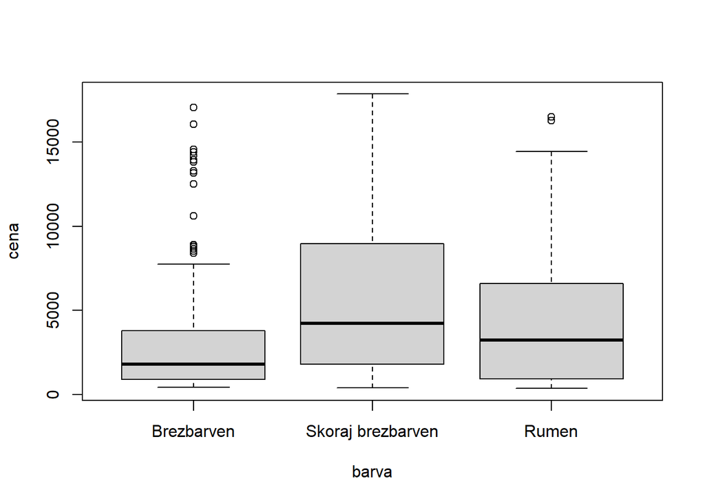

```r
boxplot(data$cena ~ data$barva,
        xlab = "barva", ylab = "cena")
```

# Naloga 4

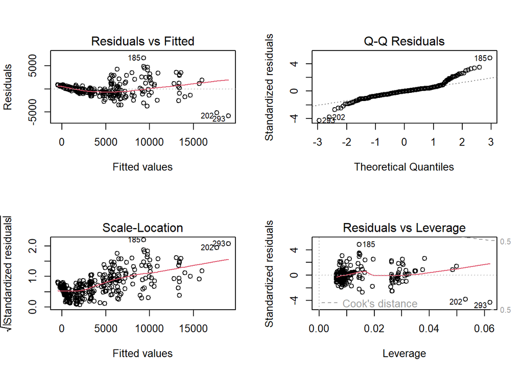

```r
model = lm(cena ~ karat + barva, data = data)

par(mfrow = c(2, 2))
plot(model)
```

Na grafih v levem stolpcu lahko vidimo, da je kršena predpostavka o konstantni varianci, kar pomeni, da je v modelu prisotna heteroskedastičnost.

Na desnem zgornjem grafu vidimo, da se tudi ostanki ne porazdeljujejo po normalni porazdelitvi. ker se ostanki oddaljujejo od diagonale na repih to kaže na preveliko število prevelikih ostankov.

# Naloga 5

```r
par(mfrow = c(1, 1))
symbox(~ cena, xlab = "Lambda",
ylab = "Transformirane vrednosti za ceno",
data = data)
```

[figure not shown]

```r
summary(powerTransform(model))
```

```
## bcPower Transformation to Normality
##    Est Power Rounded Pwr Wald Lwr Bnd Wald Upr Bnd
## Y1    0.3694        0.33       0.3031       0.4357
##
## Likelihood ratio test that transformation parameter is equal to 0
##  (log transformation)
##                            LRT df       pval
## LR test, lambda = (0) 91.59543  1 < 2.22e-16
##
## Likelihood ratio test that no transformation is needed
##                            LRT df       pval
## LR test, lambda = (1) 335.7708  1 < 2.22e-16
```

Glede na zgornji graf vidimo, da je najbolj simetričen boxplot pri 0, torej log transformaciji. Na našem modelu naredimotako odzivno kot tudi številsko napovedno spremenljivko logaritmiramo z desetiškim logaritmom, torej tako ceno kot tudi karat logaritmiramo.

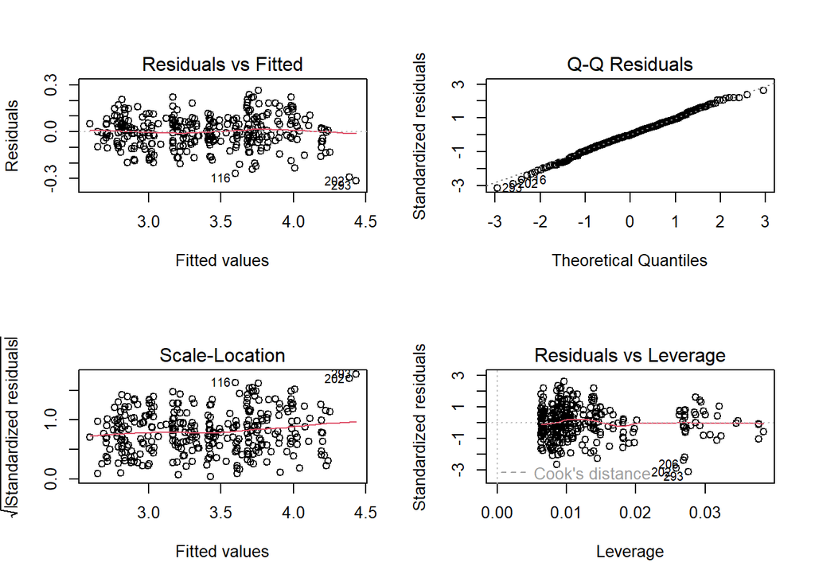

```r
model.t = lm(log10(cena) ~ log10(karat) + barva, data = data)
par(mfrow = c(2, 2))
plot(model.t)
```

Vidimo, da je zdaj diagnostika modela OK. Predpostavke so izpolnjene.

# Naloga 6

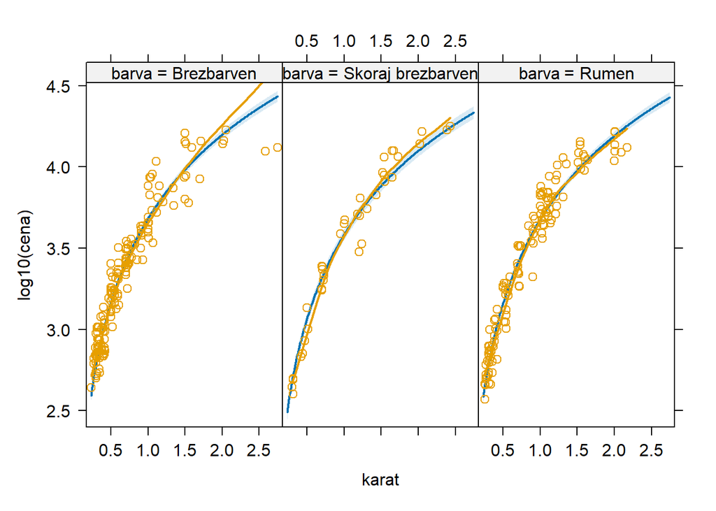

```r
plot(Effect(c("karat", "barva"), model.t, partial.residuals = TRUE),
     multiline = FALSE, ci.style = "bands",
     key.args = list(x = 0.05, y = 0.8, corner = c(0, 0)),
     main = "", lty = c(1:2))
```

```r
model.t.int = lm(log10(cena) ~ log10(karat) * barva, data = data)

anova(model.t.int)
```

```
## Analysis of Variance Table
##
## Response: log10(cena)
##                     Df Sum Sq Mean Sq   F value    Pr(>F)
## log10(karat)         1 60.647  60.647 6007.6840 < 2.2e-16 ***
## barva                2  0.304   0.152   15.0330 5.812e-07 ***
## log10(karat):barva   2  0.097   0.049    4.8099  0.008757 **
## Residuals          315  3.180   0.010
## ---
## Signif. codes:  0 '***' 0.001 '**' 0.01 '*' 0.05 '.' 0.1 ' ' 1
```

Uporabimo Sekvenčni F test. Vidimo, da interakcija pojasni več variabilnosti (je statistično značilna)

# Naloga 7

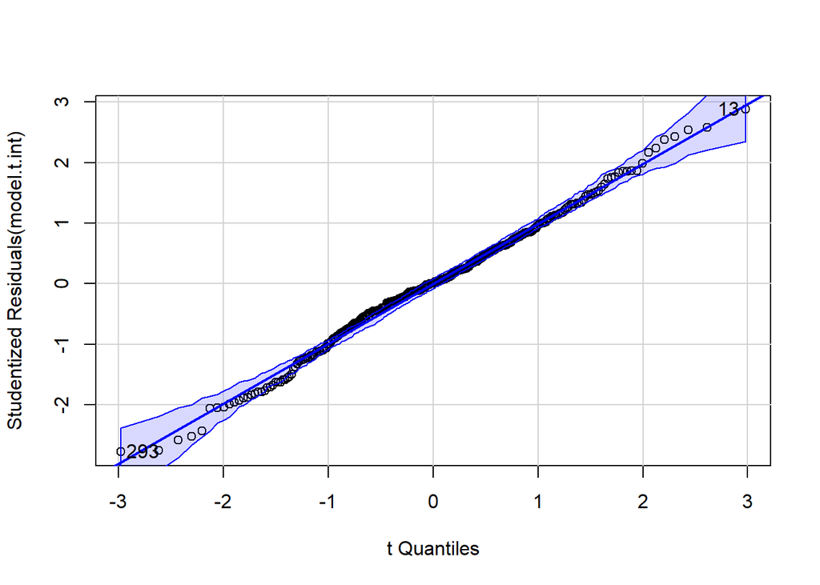

```
## [1]  13 293
```

```r
par(mfrow = c(1, 1))
qqPlot(model.t.int, id = TRUE)
```

```r
outlierTest(model.t.int)
```

```
## No Studentized residuals with Bonferroni p < 0.05
## Largest |rstudent|:
##    rstudent unadjusted p-value Bonferroni p
## 13 2.877381          0.0042846           NA
```

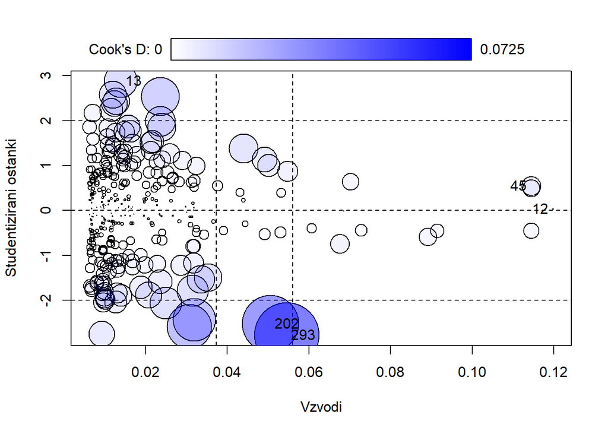

```
##         StudRes        Hat        CookD
## 12   0.03563116 0.11975987 2.888004e-05
## 13   2.87738120 0.01400211 1.915310e-02
## 45   0.54736563 0.11446257 6.468850e-03
## 202 -2.52243277 0.05060153 5.557401e-02
## 293 -2.77292370 0.05459540 7.246648e-02
```

```r
influencePlot(model.t.int,
              id = list(method = "noteworthy", n = 2, cex = 1, location = "lr"),
              xlab = "Vzvodi", ylab = "Studentizirani ostanki")
```

Glede na qq plot je kn+andidat za regresijskega osamelca enota z id = 13 vendar nam outlier test ne zavrne ničelne hipoteze, da enota ni regresijski osamelec.

na influencePlot-u vidimo, da imamo tudi nekaj vzvodnih točk npr.: 45, 12

Nimamo pa nobene vpolivne točke, kar pomeni, da modela ni potrebno spreminjati.

# 8 naloga

```r
summary(model.t.int)
```

```
##
## Call:
## lm(formula = log10(cena) ~ log10(karat) * barva, data = data)
##
## Residuals:
##       Min        1Q    Median        3Q       Max
## -0.272276 -0.055619  0.000855  0.062718  0.283808
##
## Coefficients:
##                                     Estimate Std. Error t value Pr(>|t|)
## (Intercept)                          3.66732    0.01081 339.392  < 2e-16 ***
## log10(karat)                         1.63855    0.03365  48.692  < 2e-16 ***
## barvaSkoraj brezbarven              -0.08066    0.01963  -4.109 5.07e-05 ***
## barvaRumen                           0.01480    0.01498   0.988  0.32391
## log10(karat):barvaSkoraj brezbarven  0.19665    0.07057   2.787  0.00565 **
## log10(karat):barvaRumen              0.10619    0.04791   2.216  0.02739 *
## ---
## Signif. codes:  0 '***' 0.001 '**' 0.01 '*' 0.05 '.' 0.1 ' ' 1
##
## Residual standard error: 0.1005 on 315 degrees of freedom
## Multiple R-squared:  0.9505, Adjusted R-squared:  0.9497
## F-statistic:  1209 on 5 and 315 DF,  p-value: < 2.2e-16
```

```r
confint(model.t.int)
```

```
##                                           2.5 %      97.5 %
## (Intercept)                          3.64605530  3.68857568
## log10(karat)                         1.57234358  1.70476211
## barvaSkoraj brezbarven              -0.11928889 -0.04204092
## barvaRumen                          -0.01467533  0.04428064
## log10(karat):barvaSkoraj brezbarven  0.05780763  0.33548572
## log10(karat):barvaRumen              0.01191917  0.20045412
```

```r
(b <- coefficients(model.t.int))
```

```
##                         (Intercept)                        log10(karat)
##                          3.66731549                          1.63855285
##              barvaSkoraj brezbarven                          barvaRumen
##                         -0.08066491                          0.01480266
## log10(karat):barvaSkoraj brezbarven             log10(karat):barvaRumen
##                          0.19664667                          0.10618664
```

```r
exp(b[1])
```

```
## (Intercept)
##    39.14668
```

```r
exp(confint(model.t.int)[1,])
```

```
##    2.5 %   97.5 %
## 38.32319 39.98785
```

```r
exp(b[2])-1 * 100
```

```
## log10(karat)
##    -94.85229
```

```r
exp(confint(model.t.int)[2,])-1
```

```
##    2.5 %   97.5 %
## 3.817926 4.500077
```

```r
exp(b[3])-1
```

```
## barvaSkoraj brezbarven
##            -0.07749724
```

```r
exp(confint(model.t.int)[3,])-1
```

```
##       2.5 %      97.5 %
## -0.11244864 -0.04116946
```

# 9 Naloga

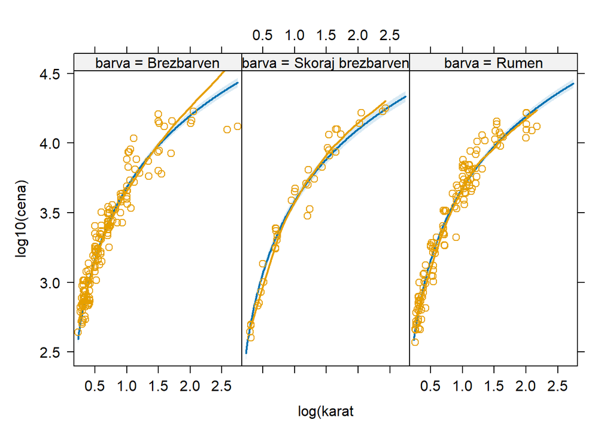

```r
plot(Effect(c("karat", "barva"), model.t, partial.residuals = TRUE),
     multiline = FALSE, ci.style = "bands",
     key.args = list(x = 0.05, y = 0.8, corner = c(0, 0)),
     main = "", lty = c(1:2), xlab = "log(karat")
```